# Job Posting Analysis

### ----------------------------------------------------------------------------------------------------------------------------

# Text Mining

### IT job classification

**(Supervised learning)**

This section seeks to classify if a job postings is related to IT sector or not

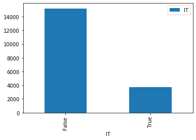

```python
data.groupby(['IT']).agg({'IT':'count'}).plot(kind='bar')
plt.grid(False)
```

**TF - IDF based classification**

```python
from sklearn.feature_extraction.text import CountVectorizer,TfidfVectorizer
```

Split train and test

```python
# define X and y
X = data.jobpost
y = data.IT

# split the new DataFrame into training and testing sets
X_train, X_test, y_train, y_test = train_test_split(X, y,test_size=0.3,random_state=1)

X_train = X_train.reset_index(drop=True)
X_test = X_test.reset_index(drop=True)
y_train = y_train.reset_index(drop=True)
y_test = y_test.reset_index(drop=True)

X_train.shape,X_test.shape,y_train.shape,y_test.shape
```

```
((13273,), (5689,), (13273,), (5689,))
```

Applying the tf-idf vectorizer on the train and test

```python
tv=TfidfVectorizer()
X_train_tv= tv.fit_transform(X_train)
X_test_tv= tv.transform(X_test)
```

```python
X_train_tv.shape, X_test_tv.shape
```

```
((13273, 21091), (5689, 21091))
```

Dimensionality reduction using Singular Value Decomposition (SVD)  
/ latent semantic analysis (LSA).

```python
from sklearn.decomposition import TruncatedSVD,PCA
```

```python
# reducing the dimensions to 1500
svd = TruncatedSVD(1500)
X_train_tv_svd = svd.fit_transform(X_train_tv)
X_test_tv_svd  = svd.transform(X_test_tv)
```

```python
print(svd.explained_variance_ratio_.sum())
```

```
0.7966755749119797
```

```python
X_train_tv_svd.shape, X_test_tv_svd.shape
```

```
((13273, 1500), (5689, 1500))
```

Over Sampling to balance the data

```python
y_train.value_counts()
```

```
False    10629
True      2644
Name: IT, dtype: int64
```

```python
from imblearn.over_sampling import SMOTE
```

```python
sm = SMOTE(random_state=42)
```

```python
X_train_sam, y_train_sam = sm.fit_sample(X_train_tv_svd, y_train)
y_train_sam.value_counts()
```

```
True     10629
False    10629
Name: IT, dtype: int64
```

```python
X_test_sam, y_test_sam = sm.fit_sample(X_test_tv_svd, y_test)
y_test_sam.value_counts()
```

```
True     4580
False    4580
Name: IT, dtype: int64
```

**Model Implementation**

- Linear SVC
- Logistic Regression

```python
def pred_rate(cls, X_train, X_test, y_train, y_test):
    # fitting
    cls.fit(X_train, y_train)
    # pred
    y_pred_train = cls.predict(X_train)
    y_pred_test = cls.predict(X_test)

    print('cm train\n',confusion_matrix(y_train, y_pred_train))
    print('cm test \n',confusion_matrix(y_test, y_pred_test))

    accuracy = accuracy_score(y_train, y_pred_train)
    print("\nAccuracy train : {} %".format(round(accuracy*100,3)))
    accuracy = accuracy_score(y_test, y_pred_test)
    print("Accuracy test  : {} %".format(round(accuracy*100,3)))

    train_auc = roc_auc_score(y_train, y_pred_train)
    test_auc  = roc_auc_score(y_test, y_pred_test)
    print("\nAUC Train : ", train_auc)
    print("AUC Test  : ", test_auc)

    print('\nClassification Report Train :')
    print(classification_report(y_train, y_pred_train))
    print('\nClassification Report Test :')
    print(classification_report(y_test, y_pred_test))
    print('-----------------------------------------------------------')
```

Linear SVC

```python
from sklearn.svm import LinearSVC
```

```python
cls_svc = LinearSVC()
```

```python
pred_rate(cls_svc, X_train_sam, X_test_sam, y_train_sam, y_test_sam)
```

```
cm train
 [[10285   344]
 [  186 10443]]
cm test
 [[4385  195]
 [ 450 4130]]

Accuracy train : 97.507 %
Accuracy test  : 92.959 %

AUC Train :  0.9750682096152037
AUC Test  :  0.929585152838428

Classification Report Train :
              precision    recall  f1-score   support

       False       0.98      0.97      0.97     10629
        True       0.97      0.98      0.98     10629

    accuracy                           0.98     21258
   macro avg       0.98      0.98      0.98     21258
weighted avg       0.98      0.98      0.98     21258


Classification Report Test :
              precision    recall  f1-score   support

       False       0.91      0.96      0.93      4580
        True       0.95      0.90      0.93      4580

    accuracy                           0.93      9160
   macro avg       0.93      0.93      0.93      9160
weighted avg       0.93      0.93      0.93      9160

-----------------------------------------------------------
```

Logistic Regression

```python
from sklearn.linear_model import LogisticRegression
```

```python
cls_log = LogisticRegression(random_state = 0)
```

```python
pred_rate(cls_log, X_train_sam, X_test_sam, y_train_sam, y_test_sam)
```

```
cm train
 [[10081   548]
 [  453 10176]]
cm test
 [[4323  257]
 [ 406 4174]]

Accuracy train : 95.291 %
Accuracy test  : 92.762 %

AUC Train :  0.9529118449524884
AUC Test  :  0.9276200873362446

Classification Report Train :
              precision    recall  f1-score   support

       False       0.96      0.95      0.95     10629
        True       0.95      0.96      0.95     10629

    accuracy                           0.95     21258
   macro avg       0.95      0.95      0.95     21258
weighted avg       0.95      0.95      0.95     21258


Classification Report Test :
              precision    recall  f1-score   support

       False       0.91      0.94      0.93      4580
        True       0.94      0.91      0.93      4580

    accuracy                           0.93      9160
   macro avg       0.93      0.93      0.93      9160
weighted avg       0.93      0.93      0.93      9160

-----------------------------------------------------------
```

Both Logistic and Linear SVC models have a test accuracy of about **92.75 %**. So both are performing well.

### ----------------------------------------------------------------------------------------------------------------------------

## Unsupervised Learning

*This section seeks to explore Job nature, Company profiles and skills demanded by the companies*

### **K Means clustering**

To understand the required qualification for the job postings.  
The records are clusteres based on the contents of the required qualifications column

```python
data.RequiredQual;
```

```python
# define X and y
X_k = data.RequiredQual

# split the new DataFrame into training and testing sets
X_k_train, X_k_test = train_test_split(X_k, test_size=0.3,random_state=1)

X_k_train = X_k_train.reset_index(drop=True)
X_k_test = X_k_test.reset_index(drop=True)

X_k_train.shape,X_k_test.shape
```

```
((13273,), (5689,))
```

Tokenization

```python
tv_k = TfidfVectorizer(max_df=0.7, min_df=3)
X_train_tv_k = tv_k.fit_transform( X_k_train )
X_test_tv_k  = tv_k.transform( X_k_test )
```

```python
X_train_tv_k.shape, X_test_tv_k.shape
```

```
((13273, 4876), (5689, 4876))
```

Dimensionality reduction using Singular Value Decomposition (SVD)  
/ latent semantic analysis (LSA).

```python
# reducing the dimensions to 1500
svd_k = TruncatedSVD(1500)
X_train_tv_k_svd = svd_k.fit_transform(X_train_tv_k)
X_test_tv_k_svd  = svd_k.transform(X_test_tv_k)
```

```python
print(svd_k.explained_variance_ratio_.sum())
```

```
0.9129747854161934
```

```python
X_train_tv_k_svd.shape, X_test_tv_k_svd.shape
```

```
((13273, 1500), (5689, 1500))
```

Finding the optimum #clusters

```python
from sklearn.cluster import KMeans
```

Silhouette analysis

**Model Implementation**

```python
def print_centroids(cm, num):
    original_space_centroids = svd_k.inverse_transform(cm.cluster_centers_)
    order_centroids = original_space_centroids.argsort()[:, ::-1]
    terms = tv_k.get_feature_names()
    for i in range(num):
        print("Cluster %d:" % i, end='')
        for ind in order_centroids[i, :10]:
            print(' %s' % terms[ind], end='')
        print()
```

7 #Clusters

```python
k_mod_7 = KMeans(n_clusters=7, max_iter=300, init='k-means++')
k_mod_7.fit(X_train_tv_k_svd)
```

```
KMeans(algorithm='auto', copy_x=True, init='k-means++', max_iter=300,
       n_clusters=7, n_init=10, n_jobs=None, precompute_distances='auto',
       random_state=None, tol=0.0001, verbose=0)
```

```python
print_centroids(k_mod_7, 7)
```

```
Cluster 0: work excellent ability russian university degree communication good strong field
Cluster 1: ability work degree management excellent year good field project least
Cluster 2: higher education work russian excellent good computer ability field year
Cluster 3: net sql web html development server good javascript cs php
Cluster 4: eager communicative confident minded punctual timely open complete manner mail
Cluster 5: accounting finance work tax financial software excellent standard good ability
Cluster 6: development software testing good design ability programming system linux plus
```

Interpretation of the 7 #Clusters solution  
**Communication** - Cluster 0: work excellent ability russian university degree communication good strong field  
**Management** - Cluster 1: ability work degree management excellent year good field project least  
**Higher education** - Cluster 2: higher education work russian excellent good computer ability field year  
**Web developer** - Cluster 3: net sql web html development server good javascript cs php  
**Communication** - Cluster 4: eager communicative confident minded punctual timely open complete manner mail  
**Accounting** - Cluster 5: accounting finance work tax financial software excellent standard good ability  
**IT test engineer** - Cluster 6: development software testing good design ability programming system linux plus

9 #Clusters

```python
k_mod_9 = KMeans(n_clusters=9, max_iter=300, init='k-means++')
k_mod_9.fit(X_train_tv_k_svd)
```

```
KMeans(algorithm='auto', copy_x=True, init='k-means++', max_iter=300,
       n_clusters=9, n_init=10, n_jobs=None, precompute_distances='auto',
       random_state=None, tol=0.0001, verbose=0)
```

```python
print_centroids(k_mod_9, 9)
```

```
Cluster 0: testing development software programming ability linux design test good science
Cluster 1: excellent work ability russian university degree communication strong field good
Cluster 2: eager communicative confident minded punctual timely open complete manner mail
Cluster 3: banking bank legislation financial economics work finance year good excellent
Cluster 4: management ability project international work excellent degree year strong development
Cluster 5: education higher work russian excellent computer good ability field relevant
Cluster 6: good work ability degree year plus university russian excellent computer
Cluster 7: accounting finance tax work software standard excellent good ability financial
Cluster 8: net sql web development html server good javascript cs database
```

11 #Clusters

```python
k_mod_11 = KMeans(n_clusters=11, max_iter=300, init='k-means++')
k_mod_11.fit(X_train_tv_k_svd)
```

```
KMeans(algorithm='auto', copy_x=True, init='k-means++', max_iter=300,
       n_clusters=11, n_init=10, n_jobs=None, precompute_distances='auto',
       random_state=None, tol=0.0001, verbose=0)
```

```python
print_centroids(k_mod_11, 11)
```

```
Cluster 0: bank credit synopsys financial accounting program loan banking office form
Cluster 1: legal accounting project financial law bank form tax software legislation
Cluster 2: marketing course credit skill business program sale english training career
Cluster 3: customer sale please career mention opportunity skill service work credit
Cluster 4: accounting financial project accountant experience mention sale opportunity software please
Cluster 5: bank sale customer marketing form client service mention skill banking
Cluster 6: project management program support manager sale activity marketing community work
Cluster 7: software development design developer web net experience test testing engineer
Cluster 8: marketing accounting career mention opportunity please test candidate product synopsys
Cluster 9: accounting system financial net synopsys network web data design management
Cluster 10: accounting financial tax accountant developer web net development child credit
```

### ----------------------------------------------------------------------------------------------------------------------------

### Named Entity Recognition

```python
import spacy
```

```python
nlp = spacy.load('en')
```

```python
def get_orgs_from_doc(document):
    doc = nlp(document)
    org_entities = ""

    for ent in doc.ents:
        stripped_content = ent.text.strip()
        if stripped_content != "" and stripped_content[0] != "-":
            if ent.label_ == "ORG":
                entity = ent.text
                entity = entity.replace("/", " ").replace("\n", " ")
                org_entities += entity + " "

    return org_entities
```

```python
qual_ORG = pd.read_pickle("qual_ORG.pkl")
```

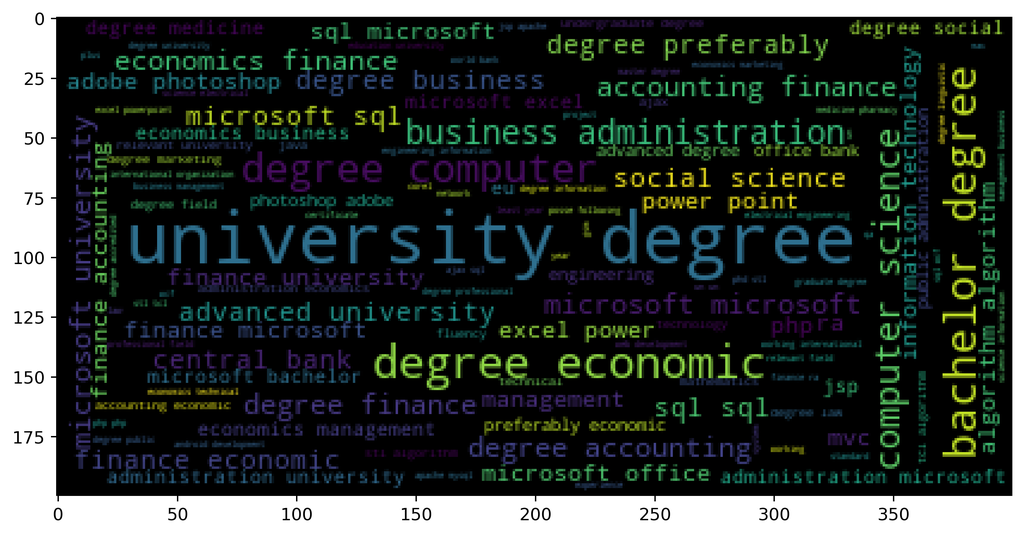

```python
wordcloud = WordCloud(stopwords=[]).generate(' '.join(qual_ORG.tolist()))
fig = plt.figure(figsize=(10,7.5),dpi=360)
plt.grid(False)
plt.imshow(wordcloud)
```

### ----------------------------------------------------------------------------------------------------------------------------